# actual_midsem_ipynb_report_22062025

I. Introduction

1. Introduction to the domain-specific area (200-500 words)
2. Objectives of the project (200-500 words)
3. Description of the selected dataset (200-500 words)
4. Evaluation methodology (200-500 words)

II. Implementation

5. Data Preprocessing
6. TF-IDF
7. Word2Vec
8. Bag-of-Words
9. Displaying the results

III. Conclusions

9. Performance Analysis & Comparative Discussion (200-500 words)
10. Project Summary and Reflections (200 to 400 words)

# INTRODUCTION

1. INTRODUCTION TO THE DOMAIN-SPECIFIC AREA

Goal:

The first step of the coursework is to identify and describe the problem or challenge. This is an area of industry or science where text classification methods can contribute. Include relevant literature to support the significance of the chosen area.

Writing:

The video game industry represents a significant and highly competitive commercial sector, with a global market value exceeding hundreds of billions of dollars. A crucial factor in a game's commercial success and longevity is its ability to meet player expectations, which are primarily communicated through user feedback. Digital distribution platforms like Steam can be a repository of feedbacks in the form of millions of user-generated reviews. The sheer volume of this data make manual analysis infeasible, creating a significant big data challenge for developers seeking to understand player sentiment, identify issues, and inform future design decisions. Therefore, the automated analysis of this user-generated text is a critical problem domain for applied Natural Language Processing (NLP).

This domain presents unique linguistic challenges that differentiate it from the analysis of more formal texts like news articles or books. Game reviews, especially from casual users with frequently takes part in Internet's culture, are a form of discourse characterised by a rich and domain-specific lexicon (Zagal et al., 2009). This includes community-specific slang (e.g., 'nerf', 'buff', 'grind'), acronyms, and in-jokes that are often absent from standard linguistic corpora. Furthermore, the language is frequently informal and emotionally charged, making heavy use of sarcasm, hyperbole, and negation, which can easily mislead sentiment analysis models that rely on simple keyword matching. For example, a review stating "This game ruined my life. 10/10" uses negative vocabulary to express a highly positive sentiment, a nuance that poses a considerable challenge for automated systems.

Moreover, the sentiment expressed in game reviews is often deeply contextual. As Zagal et al. (2009) note, reviews are not merely "shopping guides" but complex texts that often include design suggestions, historical comparisons to other games, and advice on how players should approach the game to maximize their enjoyment. This implies that player expectations are heavily influenced by factors like game genre and existing community norms. For instance, an attribute like 'complexity' may be praised in a strategy game but criticized in a casual title like a visual-novel story game. A successful analysis must be able to interpret language within these unstated contexts.

Therefore, the massive data scale, a evolving vocabulary, and complex, context-dependent sentiment makes the automated analysis of video game reviews can be a challenging yet commercially valuable application of NLP. This project will compare distinct NLP methodologies (Bag-of-Words, TF-IDF, and Word2Vec) to tackle this classification problem.

Reference:

Zagal, J.P., Ladd, A. and Johnson, T. (2009). Characterizing and understanding game reviews. Proceedings of the 4th International Conference on Foundations of Digital Games - FDG ’09. doi:https://doi.org/10.1145/1536513.1536553.

2. OBJECTIVE OF THE PROJECT

Goal:

Outline the goals of exploring both statistical and embedding-based models to understand their effectiveness and applicability in text classification tasks. State any contribution which the results may make to the challenge addressed, supported by relevant literature.

Writing:

The primary objective of this project is to conduct a comparison analysis of the traditional statistical language models and a modern embedding-based model for sentiment classification on user video game reviews. This will be done by implementing and evaluating three distinct models with a Bag-of-Words (BoW) baseline, a more sophisticated TF-IDF statistical model, and a prediction-based Word2Vec embedding model.

The findings of this project are to hopefully make a practical contribution to the domain of game review analysis, or at least, similar type of sentimental analysis as a personal hobby. As noted by Zagal et al. (2009), game reviews are a rich and varied form of discourse. By providing a clear performance benchmark between these NLP models, the results can offer guidance to developers or researchers on selecting an appropriate methodology for processing large-scale user feedback. The analysis will highlight specific scenarios where embedding-based models may offer an advantage over traditional statistical methods, mainly in capturing the semantic meaning behind the text rather than keyword frequencies. Ultimately, this project will be the practical case study on the trade-offs between interpretability, computational efficiency, and semantic understanding in modern text classification.

Reference:

Zhou, J., Ye, Z., Zhang, S., Geng, Z., Han, N. and Yang, T. (2024). Investigating response behavior through TF-IDF and Word2vec text analysis: A case study of PISA 2012 problem-solving process data. Heliyon, 10(16), p.e35945. doi:https://doi.org/10.1016/j.heliyon.2024.e35945.

Zagal, J.P., Ladd, A. and Johnson, T. (2009). Characterizing and understanding game reviews. Proceedings of the 4th International Conference on Foundations of Digital Games - FDG ’09. doi:https://doi.org/10.1145/1536513.1536553. ‌

DESCRIPTION OF THE SELECTED DATASET

Goal:

The next step is to identify a suitable dataset which is representative of the challenge and will require attention to all the steps outlined in this assignment. Provide a description of the dataset, its size, data types, the way the data were acquired. Clearly state the source of the dataset. Large technology companies, such as Microsoft, Google and Amazon, provide a wide variety of datasets. Example: ‘Fake and real news’ dataset available from the Kaggle official website.

Writing:

The dataset selected for this project is the "Steam Review Dataset (2017)," a publicly available resource for academic and non-commercial use, published by Antoni Sobkowicz on the Zenodo research data repository (Sobkowicz, 2017). With Steam being generally considered the most popular overall online game store. It boasts a massive library of games, a large user base, and innovative features that make it a dominant force in the PC gaming market. The reviews on Steam contain a large volume of informal, user-generated text with significant linguistic diversity and sentiment. Therefore, this dataset will be suitable as the representative of the challenges outlined earlier.

The dataset comprises over 6.4 million game reviews, all in English, acquired from the public-facing Steam store, a digital distribution platform operated by Valve Corporation. The data is provided as a single, bzip2 compressed Comma-Separated Values (CSV) file. Each record in the dataset corresponds to a single user review and is structured with the following data types and fields:

- app_id, An integer representing the unique identifier for the game being reviewed.
- app_name, a string containing the title of the game.
- review_text, a string containing the full text of the user's review. This field is the primary input feature for the text classification models.
- review_score, a binary integer (1 or -1) representing the sentiment of the review, where 1 signifies a positive recommendation ("Recommended") and -1 signifies a negative one ("Not Recommended"). This serves as the target variable for the classification task.
- review_votes, an integer indicating the number of other users who found the review helpful.

The initial data exploration revealed a significant class imbalance in the review_score field, with positive reviews (82.3%) vastly outnumbering negative reviews (17.7%). Furthermore, the review_text field exhibits a wide distribution of lengths, from single-word entries to multi-paragraph narratives, and contains considerable noise including internet slang, sarcasm, and non-standard formatting, making it an ideal candidate for comparing the different NLP modeling techniques.

Reference:

Antoni Sobkowicz. (2017). Steam Review Dataset (2017) [Data set]. Zenodo. https://doi.org/10.5281/zenodo.1000885

EVALUATION METHODOLOGY

Goal:

Describe the metrics (e.g., Accuracy, Precision, Recall, F1-Score) for assessing model performance and discuss how to apply these metrics to compare the two methodologies.

Writing:

The performance of the three text classification models (Bag-of-Words, TF-IDF, and Word2Vec) will be assessed using a combination of standard quantitative metrics and a qualitative error analysis.

A standard 80/20 train-test split will be used to partition the data. Considering the large scale of the dataset (6.4 million entries), all metrics will be calculated on the held-out test set, since there is no lack of data and there is a need for computationally efficiency (Training the W2V model with 6.4 million entries requires around 40 minutes for the 80/20 data split). The following metrics will be the primary measures of performance:

- Accuracy, the proportion of all predictions that the model got correct. While a common baseline, accuracy can be a misleading metric for this project due to the significant class imbalance (82.3% positive vs. 17.7% negative). A model that naively predicts "positive" for every review would achieve over 82% accuracy without any real learning. Therefore, Random OverSampling is applied to tackle this issue.
- Precision, for each class (Positive/Negative), this measures the proportion of its predictions that were actually correct. High precision for the negative class is important to ensure the model's negative predictions are trustworthy.
- Recall (Sensitivity), for each class, this measures the proportion of all actual instances that the model correctly identified. High recall for the negative class is critical, as it indicates the model's ability to identify the rare but important negative reviews.
- F1-Score, the harmonic mean of precision and recall. It provides a single, balanced score that is particularly useful for imbalanced datasets, as it penalizes models that favor high precision at the expense of recall, or vice versa. The F1-score for the minority (Negative) class will be a key indicator of a model's practical effectiveness.

The models' overall accuracy will be compared, but greater emphasis will be placed on the F1-scores for both the majority and minority classes. The primary goal is to determine which representation method (BoW, TF-IDF, or Word2Vec) yields a model that not only performs well overall but is also most effective at correctly identifying the crucial, under-represented negative reviews.

# IMPLEMENTATION

5. DATA PREPROCESSING

```python
import pandas as pd
import matplotlib.pyplot as plt
import seaborn as sns
%matplotlib inline
import re
import string
import numpy as np

from nltk.tokenize import word_tokenize
from nltk.corpus import stopwords
from nltk.stem import WordNetLemmatizer

from sklearn.model_selection import train_test_split

from sklearn.feature_extraction.text import TfidfVectorizer

from imblearn.over_sampling import RandomOverSampler

# for TF IDF
from sklearn.naive_bayes import MultinomialNB
from sklearn.metrics import classification_report, confusion_matrix, accuracy_score

#for W2V
from nltk.tokenize import word_tokenize
from gensim.models import Word2Vec
from sklearn.linear_model import LogisticRegression

#for BoW
from sklearn.feature_extraction.text import CountVectorizer
#also uses MultinomialNB()

from tabulate import tabulate
```

```python
steam_review_raw = pd.read_csv('archive/dataset_edited.csv')
steam_review_raw.head()
```

|  | app_id | app_name | review_text | review_score | review_votes |
| --- | --- | --- | --- | --- | --- |
| 0 | 10 | Counter-Strike | This will be more of a ''my experience with th... | 1.0 | 1.0 |
| 1 | 10 | Counter-Strike | This game saved my virginity. | 1.0 | 0.0 |
| 2 | 10 | Counter-Strike | • Do you like original games? • Do you like ga... | 1.0 | 0.0 |
| 3 | 10 | Counter-Strike | Easy to learn, hard to master. | 1.0 | 1.0 |
| 4 | 10 | Counter-Strike | No r8 revolver, 10/10 will play again. | 1.0 | 1.0 |

```python
for column in steam_review_raw.columns:
    print(f"{column}, contains null/NaN? : {steam_review_raw[column].isnull().values.any()}")
```

```
app_id, contains null/NaN? : False
app_name, contains null/NaN? : True
review_text, contains null/NaN? : True
review_score, contains null/NaN? : True
review_votes, contains null/NaN? : True
```

```python
steam_review_no_null = steam_review_raw.dropna(how='any',axis=0).copy()
steam_review_raw = None
for column in steam_review_no_null.columns:
    print(f"{column}, contains null/NaN? : {steam_review_no_null[column].isnull().values.any()}")
```

```
app_id, contains null/NaN? : False
app_name, contains null/NaN? : False
review_text, contains null/NaN? : False
review_score, contains null/NaN? : False
review_votes, contains null/NaN? : False
```

```
There are 5126112 Positive Reviews
There are 1100584 Negative Reviews
```

```
 [Text(-0.9347256093484267, 0.5799034706123188, 'Positive = 82.3%'),
```

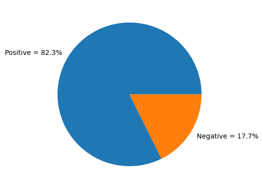

```python
positive_review_count = (steam_review_no_null['review_score'] == 1).sum()
negative_review_count = (steam_review_no_null['review_score'] == -1).sum()
print(f"There are {positive_review_count} Positive Reviews")
print(f"There are {negative_review_count} Negative Reviews")


labels = f'Positive = {round(positive_review_count/(positive_review_count + negative_review_count),3)*100}%', f'Negative = {round(negative_review_count/(positive_review_count + negative_review_count),3)*100}%'
sizes = [positive_review_count, negative_review_count]
fig, ax = plt.subplots()
ax.pie(sizes, labels=labels)
```

```python
steam_review_no_null['review_text_length'] = steam_review_no_null['review_text'].apply(lambda x: len(x.split()))
```

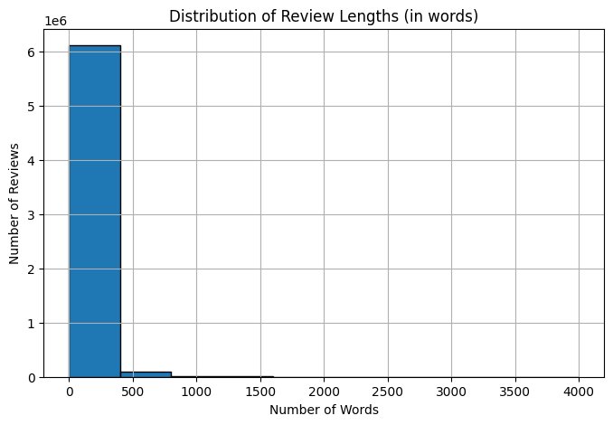

```python
plt.figure(figsize=(8, 5))
plt.hist(steam_review_no_null['review_text_length'], bins=10, edgecolor='black')
plt.title('Distribution of Review Lengths (in words)')
plt.xlabel('Number of Words')
plt.ylabel('Number of Reviews')
plt.grid(True)
plt.show()
```

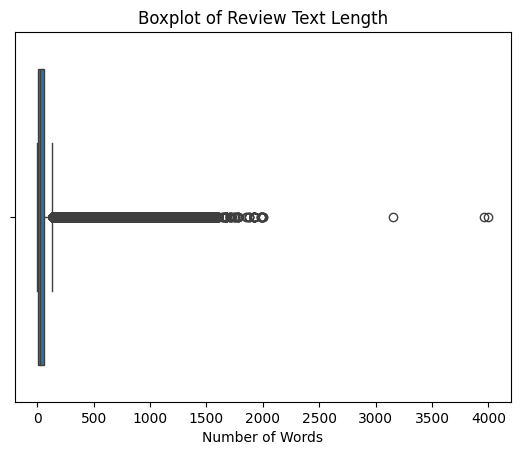

```python
sns.boxplot(x=steam_review_no_null['review_text_length'])
plt.title("Boxplot of Review Text Length")
plt.xlabel("Number of Words")
plt.show()
```

The data set contains a lot of "noise", naturally since the steam reviews contains alot of internet references, emojis, ASCII art, and special character for memes formatting

When skimming the reviews, you'll find usages of things like •, (), ~, ♥♥♥♥♥, ░░░░░░░░░░░░▄▄ , :-)

```python
from collections import Counter

# Join all reviews into one big string and count characters
all_text = ' '.join(steam_review_no_null['review_text'].dropna())
char_counts = Counter(all_text)

# Print the 20 most common and 20 least common characters
print("Most common characters:", char_counts.most_common(20))
print("Least common characters:", char_counts.most_common()[:-21:-1])
```

```
Most common characters: [(' ', 353907144), ('e', 171976393), ('t', 130731723), ('a', 119197260), ('o', 108798254), ('i', 97935844), ('s', 92018490), ('n', 90770480), ('r', 75848254), ('h', 66240622), ('l', 65606031), ('d', 47202018), ('u', 45055326), ('m', 44089084), ('g', 40607983), ('y', 38950037)…
Least common characters: [('옹', 1), ('𝘒', 1), ('렴', 1), ('籌', 1), ('俘', 1), ('陨', 1), ('栓', 1), ('抬', 1), ('ړ', 1), ('⋏', 1), ('Ꭴ', 1), ('Ꮠ', 1), ('Ꭺ', 1), ('ʱ', 1), ('ᴶ', 1), ('북', 1), ('샷', 1), ('𝓗', 1), ('𝓑', 1), ('맙', 1)]
```

Numbers can sometimes carry sentiment-relevant information (e.g., “9/10”) and they can also act as semantic shortcuts, This undermine the project's objective of evaluating sentiment classification models.

If left unprocessed, rating-like patterns (e.g., “10/10”, “0/10”) may become strong features for both TF-IDF and word embedding models. This introduces a risk where models "cheat" by relying on numerical scores rather than learning from the actual language used in the review. Such shortcuts compromise the integrity of the experiment (traditional vs. deep learning models understand linguistic sentiment).

Therefore, instead of removing entire rows that contain numbers (which would result in a significant data loss), only the numbers themselves are removed using regular expressions. Although removing all numbers might slightly lower raw model accuracy for actual usage, it improves the fairness and linguistic focus of the evaluation. The result is a more meaningful comparison of the models' capabilities in natural language understanding, which is the goals of the project.

```python
def clean_text(text):
    """
    Cleans a string of text by removing noises:
    - Removes URLs.
    - Keeps only English letters and spaces (this removes numbers, punctuation, special chars).
    - Converts to lowercase.
    - Normalizes whitespace.
    - Tokenise the reviews.
    - Remove stop words.
    - Reduces the word to its base form.
    """
    if not isinstance(text, str):
        return ""

    # Remove URLs first
    text = re.sub(r'https?://\S+|www\.\S+', '', text)

    #remove HTML tags, just in case
    text = re.sub(r'<.*?>', '', text)

    # This single regex line removes numbers, punctuation, and all non-english characters.
    # It keeps the words and the spaces between them.
    text = re.sub(r'[^a-zA-Z\s]', '', text)

    # Convert to lowercase
    text = text.lower()

    # Remove extra whitespace that might have been created
    text = re.sub(r'\s+', ' ', text).strip()

    text_token = word_tokenize(text)

    stop_words = set(stopwords.words('english'))
    text_token_no_stopword = [word for word in text_token if word not in stop_words]

    lemmatizer = WordNetLemmatizer()
    lemmatized_text_token_no_stopword = [lemmatizer.lemmatize(word) for word in text_token_no_stopword]

    return ' '.join(lemmatized_text_token_no_stopword)
```

Lemmatisation was chosen as the preferred text normalisation technique over stemming due to its accuracy and semantic preservation—key factors for this task.

- Lemmatisation reduces words to their true dictionary form (lemmas), ensuring that related words like "loved", "loving", and "loves" are correctly mapped to "love". This helps preserve the underlying sentiment more accurately than stemming, which might reduce them to crude forms like "lov" or "lovin".
- Stemming often produces non-words (e.g., "studies" → "studi"), which can lead to conflicts to similar terms with different meanings or connotations. On the other hand, lemmatisation ensures the meaningful distinctions between words are maintained, which is critical when training a model with such nuanced language.
- Clean, linguistically valid tokens produced by lemmatisation make both the input and learned features easier to understand and debug. This leads to a more transparent and robust sentiment analysis pipeline. While lemmatization is computationally more expensive than stemming, its accuracy and linguistic integrity make it the more suitable for this project.

```python
steam_review_no_null['cleaned_review'] = steam_review_no_null['review_text'].apply(clean_text)
steam_review_no_null.head()
```

|  | app_id | app_name | review_text | review_score | review_votes | review_text_length | cleaned_review |
| --- | --- | --- | --- | --- | --- | --- | --- |
| 0 | 10 | Counter-Strike | This will be more of a ''my experience with th... | 1.0 | 1.0 | 449 | experience game type review saying thing like ... |
| 1 | 10 | Counter-Strike | This game saved my virginity. | 1.0 | 0.0 | 5 | game saved virginity |
| 2 | 10 | Counter-Strike | • Do you like original games? • Do you like ga... | 1.0 | 0.0 | 47 | like original game like game dont lag like gam... |
| 3 | 10 | Counter-Strike | Easy to learn, hard to master. | 1.0 | 1.0 | 6 | easy learn hard master |
| 4 | 10 | Counter-Strike | No r8 revolver, 10/10 will play again. | 1.0 | 1.0 | 7 | r revolver play |

The original dataset encoded sentiment labels as 1 for positive and -1 for negative reviews. While this is understandable to a human reader, it is not ideal for most machine learning workflows.

The standard input format expected by scikit-learn classifiers is non-negative integers starting from 0, typically {0, 1} for binary classification. Although some algorithms can handle {-1, 1}, using {0, 1} avoids unexpected behaviour and improves overall code compatibility and reliability. Additionally, mapping the classes to 0 = Negative and 1 = Positive makes model output and evaluation metrics easier to interpret, especially when using confusion matrices or classification reports.

Furthermore, after text preprocessing (e.g., removing punctuation, symbols, and stop words), some reviews may become empty or null. These are the results of cleaning reviews typically consisting only of:

- ASCII art
- Emojis or special symbols
- Ratings or filler characters

As described earlier, while such reviews would offer meaningful textual content for actual sentiment classification task, their inclusion will affects the comparisons between the models as they study the fed data differently. Therefore, a post-cleaning step was implemented to filter out any empty or null reviews, ensuring that only valid word examples are retained in the dataset.

```python
def negative_to_0(number):
    if number == -1:
        return 0
    else:
        return number
```

```python
steam_review_no_null['review_score_cleaned'] = steam_review_no_null['review_score'].apply(negative_to_0)
steam_review_no_null_cleaned = steam_review_no_null.dropna(how='any',axis=0).copy()
steam_review_no_null = None
steam_review_no_null_cleaned.head()
```

|  | app_id | app_name | review_text | review_score | review_votes | review_text_length | cleaned_review | review_score_cleaned |
| --- | --- | --- | --- | --- | --- | --- | --- | --- |
| 0 | 10 | Counter-Strike | This will be more of a ''my experience with th... | 1.0 | 1.0 | 449 | experience game type review saying thing like ... | 1.0 |
| 1 | 10 | Counter-Strike | This game saved my virginity. | 1.0 | 0.0 | 5 | game saved virginity | 1.0 |
| 2 | 10 | Counter-Strike | • Do you like original games? • Do you like ga... | 1.0 | 0.0 | 47 | like original game like game dont lag like gam... | 1.0 |
| 3 | 10 | Counter-Strike | Easy to learn, hard to master. | 1.0 | 1.0 | 6 | easy learn hard master | 1.0 |
| 4 | 10 | Counter-Strike | No r8 revolver, 10/10 will play again. | 1.0 | 1.0 | 7 | r revolver play | 1.0 |

```python
steam_review_no_null_cleaned.to_csv('archive/steam_reviews_cleaned.csv', index=False)
steam_review_no_null_cleaned = None
```

In this project, the idea is to have the sentiment classifiers trained exclusively on the review text. Excluding the game's title (app_name) ensure the integrity and generalisability of the model:

- Including the game title risks introducing "target leakage". Some games are overwhelmingly associated with a particular sentiment (e.g., Portal 2 with positive reviews), allowing the model to "cheat" by learning game-based shortcuts rather than the reviews' true sentiment patterns. This would produce inflated accuracy scores while undermining the model’s capability when reviewing unseen games.
- The goal is to build a model that understands sentiment expressed through language, not one that memorises which games are popular. The models should aim to classify phrases like “a broken mess” or “a masterpiece” than the name itself.

However, while excluding the game title avoids data leakage, it does limit the model’s understanding of game-specific sentiment context. Terms like “slow-paced” or “complex” can have different meanings depending on genre—positive in a strategy game, but negative in a shooter. For now, to ensure consistent and fair comparison, only the cleaned reviews are set as the feature to be fed into the models.

```python
steam_review = pd.read_csv('archive/steam_reviews_cleaned.csv')
steam_review.head()
```

|  | app_id | app_name | review_text | review_score | review_votes | review_text_length | cleaned_review | review_score_cleaned |
| --- | --- | --- | --- | --- | --- | --- | --- | --- |
| 0 | 10 | Counter-Strike | This will be more of a ''my experience with th... | 1.0 | 1.0 | 449 | experience game type review saying thing like ... | 1.0 |
| 1 | 10 | Counter-Strike | This game saved my virginity. | 1.0 | 0.0 | 5 | game saved virginity | 1.0 |
| 2 | 10 | Counter-Strike | • Do you like original games? • Do you like ga... | 1.0 | 0.0 | 47 | like original game like game dont lag like gam... | 1.0 |
| 3 | 10 | Counter-Strike | Easy to learn, hard to master. | 1.0 | 1.0 | 6 | easy learn hard master | 1.0 |
| 4 | 10 | Counter-Strike | No r8 revolver, 10/10 will play again. | 1.0 | 1.0 | 7 | r revolver play | 1.0 |

Although K-Fold Cross-Validation is a popular approach for these type of works, this project uses a more simple train-test split due to the following key considerations:

- Cross-validation requires training and evaluating the model multiple times, which is computationally expensive—especially with large datasets and high-dimensional feature extraction methods like TF-IDF. A single split dramatically reduces runtime and allows for faster experimentation and debugging. For example, producing of the w2v_model variable with 80% of the tokenised dataset requires 45 minutes. Therefore, applying K-Fold Cross-Validation where k = 5 would be detrimental in managing time for this project.
- The dataset used is large (approximately 2GB), containing millions of entries. An 80/20 train-test split, or even smaller, would provides a sufficiently large and representative test set. With such volume, performance estimates from a single split are generally stable.
- The primary aim of this project is to compare two different text representation methods. Cross-validation would add unnecessary complexity without offering significant benefits to each of the model's output. Thus, diverting attention from the core comparative analysis.
- While K-Fold CV would yield performance metrics with a standard deviation, offering a more in-depth evaluation, the minimal improvement is not justified by the added computational cost and code complexity with the consideration of the dataset’s scale.

```python
steam_review_no_null_2 = steam_review.dropna(how='any',axis=0).copy()
steam_review = None
X = steam_review_no_null_2['cleaned_review']
y = steam_review_no_null_2['review_score_cleaned']
_, df_temp, _, _ = train_test_split(X, y,test_size=1000000,stratify=y,random_state=42) # to reduce the entry count to 1 million.
df_temp = pd.concat([df_temp, y.loc[df_temp.index]], axis=1)
steam_review_no_null_2 = None
df_temp.head()
```

|  | cleaned_review | review_score_cleaned |
| --- | --- | --- |
| 2314436 | lot rhythm game probably played yet single gam... | 1.0 |
| 3864688 | great rally simulator perhaps best date need m... | 1.0 |
| 4382151 | early access review | 1.0 |
| 5901754 | there adage dota community often quote someone... | 1.0 |
| 4925601 | word person enjoys game text speech type brbrb... | 1.0 |

The reason for limiting the training data to just one million entries lies with the computational power of the device used for this project. Here is the error I once received when training the W2V model with the entire dataset:

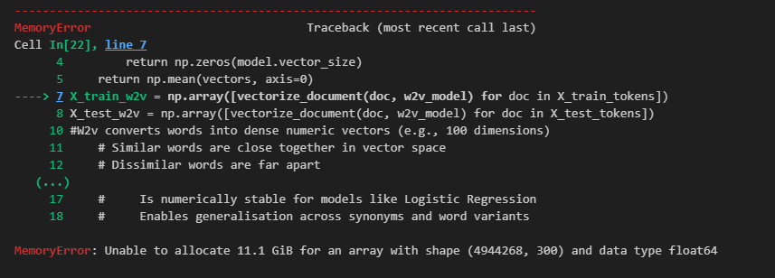

```python
X = df_temp['cleaned_review']
y = df_temp['review_score_cleaned']
X_train, X_test, y_train, y_test = train_test_split(X, y, test_size=0.2, random_state=4, stratify=y)
```

```python
ROS = RandomOverSampler(random_state=42)
```

That being said, Oversampling is applied right before training the models. Applying oversampling beforehand would alter the document frequency statistics, leading to distorted values especially for TF-IDF and BoW. Thus, compromise their feature integrity.

6. TF-IDF IMPLEMENTATION

```python
tfidf = TfidfVectorizer()
X_train_tfidf = tfidf.fit_transform(X_train)
X_test_tfidf  = tfidf.transform(X_test)

X_tfidf_ros, y_train_ros = ROS.fit_resample(X_train_tfidf, y_train)
```

```python
nb_classifier_tfidf = MultinomialNB()
nb_classifier_tfidf.fit(X_tfidf_ros,y_train_ros)
y_pred_tfidf = nb_classifier_tfidf.predict(X_test_tfidf)
```

```python
accuracy_tfidf = accuracy_score(y_test,y_pred_tfidf)

report_tfidf = classification_report(y_test, y_pred_tfidf, target_names=['Negative', 'Positive'],output_dict=True)
# print("\nTF-IDF Classification Report:")
# print(report_tfidf)

cm_tfidf = confusion_matrix(y_test, y_pred_tfidf)
# print("\nTF-IDF Confusion Matrix:")
# print(cm_tfidf)
```

7. Word2Vec

```python
X_train_tokens = [word_tokenize(review) for review in X_train]
X_test_tokens = [word_tokenize(review) for review in X_test]
```

```python
w2v_model = Word2Vec(sentences=X_train_tokens,
                     vector_size=300, # Size of the embedding vector
                     window=5, # Context window size
                     min_count=2, # Minimum word frequency
                     workers=4) # Number of CPU cores/threads
```

```python
def vectorize_document(doc, model):
    vectors = [model.wv[word] for word in doc if word in model.wv]
    if len(vectors) == 0:
        return np.zeros(model.vector_size)
    return np.mean(vectors, axis=0)

X_train_w2v = np.array([vectorize_document(doc, w2v_model) for doc in X_train_tokens])
X_test_w2v = np.array([vectorize_document(doc, w2v_model) for doc in X_test_tokens])

#W2v converts words into dense numeric vectors (e.g., 100 dimensions)
    # Similar words are close together in vector space
    # Dissimilar words are far apart

    # Preserve semantic relationships.
    # Similar words have similar vectors.
    # Turns a text document into a dense and compact feature vector, which:
    #     Is numerically stable for models like Logistic Regression
    #     Enables generalisation across synonyms and word variants
```

```python
X_train_w2v_res, y_train_w2v_res = ROS.fit_resample(X_train_w2v, y_train)
```

```python
lr_classifier_w2v = LogisticRegression(max_iter=1000)
lr_classifier_w2v.fit(X_train_w2v_res, y_train_w2v_res)
y_pred_w2v = lr_classifier_w2v.predict(X_test_w2v)

#  Why does this work?
#     Each document is now a dense vector capturing the meaning of its words
#     Logistic Regression learns boundaries between positive/negative (or other) reviews based on these semantic signals
#     It generalises better than TF-IDF when synonyms or rewordings appear
```

```python
accuracy_w2v = accuracy_score(y_test, y_pred_w2v)
report_w2v = classification_report(y_test, y_pred_w2v, target_names=['Negative', 'Positive'],output_dict=True)
cm_w2v = confusion_matrix(y_test, y_pred_w2v)

# print(f"\nWord2Vec Model Accuracy: {accuracy_w2v}")
# print("\nWord2Vec Classification Report:")
# print(report_w2v)
# print("\nWord2Vec Confusion Matrix:")
# print(cm_w2v)
```

8. Bag of Words

```python
bow_vectorizer = CountVectorizer()
X_train_bow = bow_vectorizer.fit_transform(X_train)
X_test_bow = bow_vectorizer.transform(X_test)
```

```python
X_train_bow_res, y_train_res = ROS.fit_resample(X_train_bow, y_train)
```

```python
nb_classifier_bow = MultinomialNB()
nb_classifier_bow.fit(X_train_bow_res, y_train_res)
y_pred_bow = nb_classifier_bow.predict(X_test_bow)
```

```python
accuracy_bow = accuracy_score(y_test, y_pred_bow)
report_bow = classification_report(y_test, y_pred_bow, target_names=['Negative', 'Positive'],output_dict=True)
cm_bow = confusion_matrix(y_test, y_pred_bow)

# print(f"\nBag-of-Words Model Accuracy: {accuracy_bow}")
# print("\nBag-of-Words Classification Report:")
# print(report_bow)
# print("\nBag-of-Words Confusion Matrix:")
# print(cm_bow)
```

9. DISPLAYING THE RESULTS

```python
#Accuracy and Confusion Matrices
```

```
Bag-of-Words Model Accuracy: 0.821605

Bag-of-Words Classification Report:
              precision    recall  f1-score        support
Negative       0.496915  0.671433  0.571140   35384.000000
Positive       0.923608  0.853884  0.887379  164616.000000
accuracy       0.821605  0.821605  0.821605       0.821605
macro avg      0.710262  0.762659  0.729259  200000.000000
weighted avg   0.848118  0.821605  0.831430  200000.000000
```

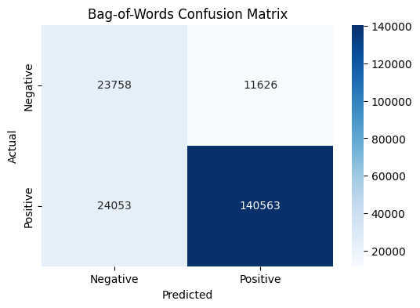

```python
#BoW
print(f"\nBag-of-Words Model Accuracy: {accuracy_bow}")

report_bow_df = pd.DataFrame(report_bow).transpose()
print("\nBag-of-Words Classification Report:")
print(report_bow_df)

# Plot as heatmap
plt.figure(figsize=(6, 4))
sns.heatmap(cm_bow, annot=True, fmt='d', cmap='Blues',
            xticklabels=['Negative', 'Positive'],
            yticklabels=['Negative', 'Positive'])

plt.title('Bag-of-Words Confusion Matrix')
plt.xlabel('Predicted')
plt.ylabel('Actual')
plt.show()
```

```
TF-IDF Model Accuracy: 0.72422

TF-IDF Classification Report:
              precision    recall  f1-score       support
Negative       0.378200  0.867539  0.526761   35384.00000
Positive       0.960558  0.693414  0.805412  164616.00000
accuracy       0.724220  0.724220  0.724220       0.72422
macro avg      0.669379  0.780476  0.666086  200000.00000
weighted avg   0.857528  0.724220  0.756113  200000.00000
```

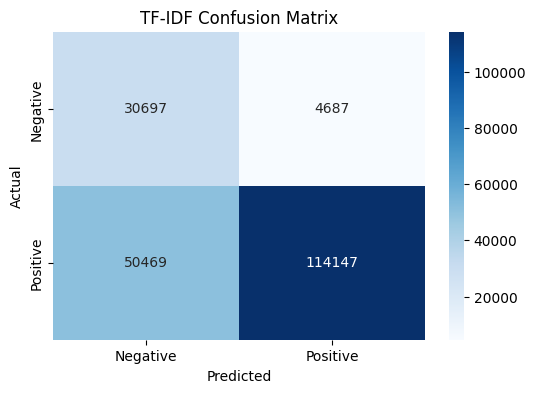

```python
#TFIDF
print(f"\nTF-IDF Model Accuracy: {accuracy_tfidf}")

report_tfidf_df = pd.DataFrame(report_tfidf).transpose()
print("\nTF-IDF Classification Report:")
print(report_tfidf_df)

# Plot as heatmap
plt.figure(figsize=(6, 4))
sns.heatmap(cm_tfidf, annot=True, fmt='d', cmap='Blues',
            xticklabels=['Negative', 'Positive'],
            yticklabels=['Negative', 'Positive'])

plt.title('TF-IDF Confusion Matrix')
plt.xlabel('Predicted')
plt.ylabel('Actual')
plt.show()
```

```
Word2Vec Model Accuracy: 0.727625

Word2Vec Classification Report:
              precision    recall  f1-score        support
Negative       0.381093  0.864600  0.529012   35384.000000
Positive       0.959983  0.698182  0.808415  164616.000000
accuracy       0.727625  0.727625  0.727625       0.727625
macro avg      0.670538  0.781391  0.668713  200000.000000
weighted avg   0.857565  0.727625  0.758983  200000.000000
```

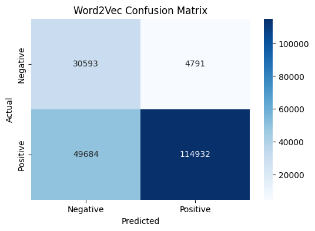

```python
#W2V
print(f"\nWord2Vec Model Accuracy: {accuracy_w2v}")

report_w2v_df = pd.DataFrame(report_w2v).transpose()
print("\nWord2Vec Classification Report:")
print(report_w2v_df)

# Plot as heatmap
plt.figure(figsize=(6, 4))
sns.heatmap(cm_w2v, annot=True, fmt='d', cmap='Blues',
            xticklabels=['Negative', 'Positive'],
            yticklabels=['Negative', 'Positive'])

plt.title('Word2Vec Confusion Matrix')
plt.xlabel('Predicted')
plt.ylabel('Actual')
plt.show()
```

```python
#Qualitative Error Analysis
selected_review = pd.read_csv('archive/selected_reviews.csv')
selected_review.head()
```

|  | app_id | app_name | review_text | review_score | review_votes |
| --- | --- | --- | --- | --- | --- |
| 0 | 99910 | Puzzle Pirates | valve pls why...3spooky5me cant handel | -1 | 0 |
| 1 | 380220 | Hover Junkers | https://www.youtube.com/watch?v=VgAZhIoNLjE | 1 | 0 |
| 2 | 359550 | Tom Clancy's Rainbow Six Siege | -Be me -Play Rainbow 6 seige -Waited for 3 m... | -1 | 0 |
| 3 | 359550 | Tom Clancy's Rainbow Six Siege | Great game had to run it 30 sec and it did mak... | -1 | 0 |
| 4 | 290300 | Rebel Galaxy | Scratches the freelancer itch - I'm trading, u... | 1 | 0 |

```python
review_text_col = selected_review["review_text"]
print(review_text_col)
```

```
0                valve pls why...3spooky5me cant handel
1          https://www.youtube.com/watch?v=VgAZhIoNLjE
2       -Be me -Play Rainbow 6 seige -Waited for 3 m...
3     Great game had to run it 30 sec and it did mak...
4     Scratches the freelancer itch - I'm trading, u...
5     This game is way too goat for me. I simply can...
6     Let me out, what you see is not the same perso...
7     Log: day 1:  I've bought a game called Cities:...
8                              Makes you really hate EA
9     How to play Cities: Skylines:  YOU DON'T.  10/...
10    This game beats simcity 5 By 16000000000000000...
11    MAKOTO IS SUPERIOR WAIFU, THOUGH SHE CANNOT CO...
12    Day one of Japan and already I have been p!sse...
13    No. You need to level up to use basic ♥♥♥♥ing ...
14    do not down;oad mods it will destroy your game...
15                                    for mother russia
16                                      Ruined my life.
17    Okay, one of my serious reviews, but you're pr...
18                             Killed by a fly    10/10
19    Yet another great game ruined by its community...
20                                  ♥♥♥♥ing cod rip off
21    Probably the black sheep of the postal series,...
22                 ♥♥♥♥ S H I T S H I T S H I T S H I T
Name: review_text, dtype: object
```

```
There are 12 Positive Reviews
There are 11 Negative Reviews
```

```
 [Text(-0.07506663683168735, 1.097435647331897, 'Positive = 52.2%'),
```

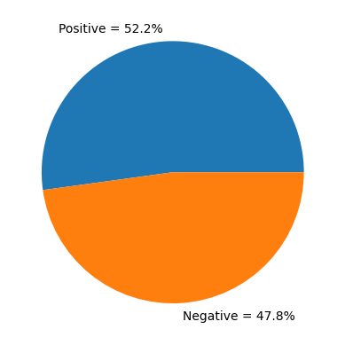

```python
positive_review_count = (selected_review['review_score'] == 1).sum()
negative_review_count = (selected_review['review_score'] == -1).sum()
print(f"There are {positive_review_count} Positive Reviews")
print(f"There are {negative_review_count} Negative Reviews")


labels = f'Positive = {round(positive_review_count/(positive_review_count + negative_review_count),3)*100}%', f'Negative = {round(negative_review_count/(positive_review_count + negative_review_count),3)*100}%'
sizes = [positive_review_count, negative_review_count]
fig, ax = plt.subplots()
ax.pie(sizes, labels=labels)
```

```python
selected_review['cleaned_review'] = selected_review['review_text'].apply(clean_text)
selected_review['review_score_cleaned'] = selected_review['review_score'].apply(negative_to_0)
X_qea = selected_review['cleaned_review']
y_qea = selected_review['review_score_cleaned']
```

```python
print(X_qea)
```

```
0                     valve pls whyspookyme cant handel
1
2     play rainbow seige waited minute search teamma...
3     great game run sec make computer crash great p...
4     scratch freelancer itch im trading upgrading d...
5      game way goat simply handle great goat therefore
6     let see person life lie im youre looking let s...
7     log day ive bought game called city skyline do...
8                                   make really hate ea
9                  play city skyline dont computer suck
10                           game beat simcity triilion
11    makoto superior waifu though cook smart well l...
12        day one japan already pssed toilet never hold
13    need level use basic ing unit like mortardid b...
14    downoad mod destroy game download mod face con...
15                                        mother russia
16                                          ruined life
17    okay one serious review youre probably wonderi...
18                                           killed fly
19    yet another great game ruined community people...
20                                          ing cod rip
21    probably black sheep postal series peice crap ...
22                                              h h h h
Name: cleaned_review, dtype: object
```

```python
# tfidf
X_qea_tfidf  = tfidf.transform(X_qea)
y_qea_pred_tfidf = nb_classifier_tfidf.predict(X_qea_tfidf)
```

```python
# w2v
X_qea_tokens = [word_tokenize(review) for review in X_qea]
X_qea_w2v = np.array([vectorize_document(doc, w2v_model) for doc in X_qea_tokens])
y_qea_pred_w2v = lr_classifier_w2v.predict(X_qea_w2v)
```

```python
# bow
X_qea_bow = bow_vectorizer.transform(X_qea)
y_qea_pred_bow = nb_classifier_bow.predict(X_qea_bow)
```

```python
headers = ["Review","True Sentiment", "BoW Prediction", "TF-IDF Prediction","W2V Prediction"]
data = []
for i in range(len(review_text_col)):
    temp = []
    temp.append(review_text_col[i] if len(review_text_col[i]) < 60 else review_text_col[i][:57]+"...")
    temp.append("Positive" if y_qea[i] == 1 else "Negative")
    temp.append("✅" if y_qea_pred_bow[i] == y_qea[i] else "❌")
    temp.append("✅" if y_qea_pred_tfidf[i] == y_qea[i] else "❌")
    temp.append("✅" if y_qea_pred_w2v[i] == y_qea[i] else "❌")
    data.append(temp)
    # Add an empty row for spacing
    data.append(["" for _ in headers])
print(tabulate(data, headers=headers))
```

```
Review                                                        True Sentiment    BoW Prediction    TF-IDF Prediction    W2V Prediction
------------------------------------------------------------  ----------------  ----------------  -------------------  ----------------
valve pls why...3spooky5me cant handel                        Negative          ✅                ✅                   ✅

https://www.youtube.com/watch?v=VgAZhIoNLjE                   Positive          ❌                ❌                   ❌

-Be me -Play Rainbow 6 seige -Waited for 3 minutes to s...    Negative          ✅                ✅                   ✅

Great game had to run it 30 sec and it did make my comput...  Negative          ✅                ✅                   ❌

Scratches the freelancer itch - I'm trading, upgrading, a...  Positive          ✅                ✅                   ✅

This game is way too goat for me. I simply cannot handle ...  Negative          ❌                ❌                   ❌

Let me out, what you see is not the same person as me My ...  Negative          ❌                ❌                   ❌

Log: day 1:  I've bought a game called Cities: Skylines. ...  Positive          ✅                ✅                   ✅

Makes you really hate EA                                      Positive          ❌                ❌                   ❌

How to play Cities: Skylines:  YOU DON'T.  10/10 my compu...  Positive          ❌                ❌                   ✅

This game beats simcity 5 By 1600000000000000000000000000...  Positive          ✅                ✅                   ✅

MAKOTO IS SUPERIOR WAIFU, THOUGH SHE CANNOT COOK, SHE HAS...  Positive          ✅                ✅                   ✅

Day one of Japan and already I have been p!ssed on by a t...  Positive          ✅                ✅                   ✅

No. You need to level up to use basic ♥♥♥♥ing units like ...  Negative          ✅                ✅                   ❌

do not down;oad mods it will destroy your game download m...  Negative          ❌                ❌                   ❌

for mother russia                                             Positive          ✅                ✅                   ✅

Ruined my life.                                               Positive          ❌                ❌                   ❌

Okay, one of my serious reviews, but you're probably wond...  Positive          ✅                ✅                   ✅

Killed by a fly    10/10                                      Positive          ❌                ✅                   ✅

Yet another great game ruined by its community. 4/5 peopl...  Negative          ✅                ✅                   ✅

♥♥♥♥ing cod rip off                                           Negative          ✅                ✅                   ✅

Probably the black sheep of the postal series, this peice...  Negative          ✅                ✅                   ✅

♥♥♥♥ S H I T S H I T S H I T S H I T                          Negative          ✅                ✅                   ❌
```

# CONCLUSION

9. PERFORMANCE ANALYSIS AND COMPARATIVE DISCUSSION

Goal:

Present and analyze the results for both models. Use visualizations to compare performance across different classes and discuss any significant findings. Critically evaluate the advantages and disadvantages of statistical and embedding-based models based on the results. Discuss scenarios where one might be preferred over the other and hypothesize reasons for observed performance disparities.

Writing:

The performance of the three models (Bag-of-Words, TF-IDF, and Word2Vec) was evaluated to compare the effectiveness of traditional statistical methods against modern embedding-based approaches for sentiment classification. While the BoW model achieved a high overall accuracy (82.1%), a deeper analysis of the other aspects reveals that this was largely a result of its bias due to the imbalanced dataset (Positive = 82.3%, Negative = 17.7%). The TF-IDF and Word2Vec models, despite lower accuracy scores (~72%), demonstrated a far superior and more practical ability to identify the crucial minority (Negative) class.

The key lies in the models' recall for negative reviews. As shown in the confusion matrices, the TF-IDF and Word2Vec models correctly identified roughly 86% of all negative reviews, a significant improvement over the BoW model's 67%. This indicates that while the BoW model's precision was higher, it failed to find a substantial portion of negative reviews, making it unreliable for practical applications like identifying customer complaints. THus, the TF-IDF and Word2Vec models, proved far more effective at this task, albeit at the cost of lower precision.

Despite with Word2Vec showing only a marginal advantage (Macro F1-Score of 0.669 vs. 0.666), the true distinction is shown in the qualitative error analysis. The Word2Vec model demonstrated a unique strength in handling complex context and sarcasm where no explicit positive keywords were present. For instance, it correctly classified the review "How to play Cities: Skylines: YOU DON'T..." as positive, while both statistical models failed. This success suggests Word2Vec learned the positive semantic pattern associated with this type of user humor, an advantage derived from its dense, prediction-based embeddings. Similarly, the BoW model saw "killed" and failed but the TF-IDF and Word2Vec succeeded. This suggests that in the broader context of the training data, the word "fly" (one of the enemy from "The Binding of Isaac") appeared so overwhelmingly in positive reviews that its positive signal outweighed the negative signal of "killed". The TF-IDF model might have learned this through statistical co-occurrence, and the Word2Vec model might have learned this through semantic proximity. This is an example showing TF-IDF and W2V understanding "contexts".

However, the analysis also revealed scenarios where the embedding-based approach has disadvantages. In the review "Great game had to run it 30 sec and it did make my computer crash,..." both BoW and TF-IDF correctly identified the negative sentiment, likely due to the strong signal from the keyword 'crash'. Word2Vec failed, indicating that averaging semantic vectors may sometimes dilute the impact of a decisive negative term when mixed with a positive phrase like "great game."

10. Project Summary and Reflections

Goal:

Reflect on the learning experience, the practicality of each model type, and their potential applications in real-world scenarios. Describe its contributions to the problem area and discuss the extent to which your solution is transferable to other domain-specific areas. Suggest improvements and future research directions.

Writing:

This project's goal is to perform comparative study of the three NLP models (Bag-of-Words, TF-IDF, and Word2Vec) for the task of sentiment classification on a large dataset of Steam game reviews. The primary contribution was the practical demonstration of these techniques in a domain known for informal language, sarcasm, and "noises" from virtual expressions. The results confirmed that while traditional statistical models like TF-IDF and BoW are still highly effective, the semantic representations of Word2Vec offer a distinct advantage in interpreting nuanced, contextual language, even if its aggregate performance was not dramatically superior in this specific implementation. However, that said, the performance difference between the models would have been more significant if this project is not held back by the device's computational prowess (The models are trained with 1 million data entries instead of the entire dataset, 6.4 million entries).

The first key learning experience was this project underscored the importance of data preprocessing and exploration. The discovery of the dataset's class imbalance and how "noises" used in reviews, necessitate the use of oversampling on the training data and clean all form of "noises" respectively to enable a meaningful comparison. Without this step, the performance of the models would have been unfair, for example, W2V may use the "rating numbers" as a crutch to cheat and understand the semantic of the review. Secondly, the limitations of quantitative metrics. While F1-scores provided a general measure of performance, the qualitative error analysis was helpful for understanding why models failed, revealing their respective weaknesses in handling complex human language nuances.

From a practical standpoint, each model type has distinct applications. The TF-IDF model, computationally efficient and highly effective at keyword-based tasks, is well-suited for scenarios requiring fast, large-scale document categorisation or information retrieval. The Word2Vec model, while more computationally intensive to train, is more applicable to scenarios where understanding user intent and semantic meaning is crucial, such as chatbot development.

The solution developed here is highly transferable to other domains involving user-generated text, such as product reviews, social media comments, or support ticket analysis, as they share similar challenges of informal language and data imbalance.

Future research could further extend this work. To improve performance, one could implement contextualized models like BERT, which might better resolve the sarcastic and contradictory language identified in the error analysis. Another improvement would be to incorporate genre and "noises" in reviews as features, allowing the model to learn context-specific sentiment (e.g., that 'grind' may be positive in an RPG but negative in another genre, and how some ASCII art in reviews may correlate to positive reviews). Finally, to improve my method of training NLP models as with my current method, I am unable to utilise the entire Steam review dataset and more.

--